# Processing Pipeline for Zebrafish Data from Farrell *et al* (2018)

- Show All Code
- Hide All Code
- View Source

Bacher Group

Author

Affiliation

Jack R. Leary

University of Florida

Published

February 28, 2025

# 1 Libraries

Before we begin, we load all the necessary libraries in R & Python.

## 1.1 R

```r
library(dplyr)       # data manipulation
library(scLANE)      # trajectory DE
library(Seurat)      # scRNA-seq tools
library(ggplot2)     # pretty plots
library(tradeSeq)    # more trajectory DE
library(slingshot)   # pseudotime inference
library(patchwork)   # plot alignment
library(reticulate)  # Python interface
rename <- dplyr::rename
reduce <- purrr::reduce
```

## 1.2 Python

```python
import pandas as pd           # DataFrame tools
import cellrank as cr         # zebrafish dataset
from scipy.io import mmwrite  # sparse matrix I/O
```

# 2 Visualization tools

We define a few color palettes to make our plots look nice.

```r
palette_heatmap <- paletteer::paletteer_d("wesanderson::Zissou1")
palette_timepoint <- paletteer::paletteer_d("ggsci::category20_d3")
palette_cluster <- paletteer::paletteer_d("ggsci::default_igv")
palette_lineage <- paletteer::paletteer_d("MetBrewer::Juarez")
```

# 3 Data

## 3.1 Pull data with `CellRank`

We start by loading in the zebrafish dataset included in the `CellRank` package.

```python
ad_fish = cr.datasets.zebrafish()
```

```python
ad_fish.obs.reset_index(inplace=False) \
           .rename(columns={'index': 'cell'}) \
           .to_csv('/blue/rbacher/j.leary/repos/scLANE-Paper/Data/zebrafish_obs.csv')
ad_fish.var.reset_index(inplace=False) \
           .rename(columns={'index': 'gene'}) \
           .to_csv('/blue/rbacher/j.leary/repos/scLANE-Paper/Data/zebrafish_var.csv')
mmwrite('/blue/rbacher/j.leary/repos/scLANE-Paper/Data/zebrafish_counts.mtx', a=ad_fish.X)
pd.DataFrame(ad_fish.obsm['X_force_directed']) \
  .rename(columns={0: 'F1', 1: 'F2', 2: 'F3'}) \
  .to_csv('/blue/rbacher/j.leary/repos/scLANE-Paper/Data/zebrafish_graph_embed.csv')
```

## 3.2 Read data into R

Next, we read the cell- and gene-level metadata, counts matrix, and force-directed graph embedding into R. Expand the code block for details.

```r
ad_fish_obs <- readr::read_csv("/blue/rbacher/j.leary/repos/scLANE-Paper/Data/zebrafish_obs.csv",
                               col_names = TRUE,
                               show_col_types = FALSE,
                               col_select = -1) %>%
               as.data.frame() %>%
               magrittr::set_rownames(.$cell)
ad_fish_var <- readr::read_csv("/blue/rbacher/j.leary/repos/scLANE-Paper/Data/zebrafish_var.csv",
                               col_names = TRUE,
                               show_col_types = FALSE,
                               col_select = -1) %>%
               as.data.frame() %>%
               magrittr::set_rownames(.$gene)
ad_fish_embed <- readr::read_csv("/blue/rbacher/j.leary/repos/scLANE-Paper/Data/zebrafish_graph_embed.csv",
                                 col_names = TRUE,
                                 show_col_types = FALSE,
                                 col_select = -1) %>%
                 as.matrix()
rownames(ad_fish_embed) <- ad_fish_obs$cell
counts_mtx <- Matrix::readMM("/blue/rbacher/j.leary/repos/scLANE-Paper/Data/zebrafish_counts.mtx")
counts_mtx <- as(counts_mtx, "dgCMatrix")
colnames(counts_mtx) <- ad_fish_var$gene
rownames(counts_mtx) <- ad_fish_obs$cell
counts_mtx <- Matrix::t(counts_mtx)
na_cells <- which(rowSums(is.na(ad_fish_embed)) != 0)
ad_fish_obs <- ad_fish_obs[-na_cells, ]
ad_fish_embed <- ad_fish_embed[-na_cells, ]
counts_mtx <- counts_mtx[, -na_cells]
```

## 3.3 Create `Seurat` object

With our data in hand we create a `Seurat` object.

```r
seu_fish <- CreateSeuratObject(counts = counts_mtx,
                               project = "zebrafish",
                               assay = "RNA",
                               meta.data = ad_fish_obs,
                               min.cells = 5,
                               min.features = 0)
graph_embed <- CreateDimReducObject(ad_fish_embed,
                                    assay = "RNA",
                                    key = "FR_",
                                    global = TRUE)
seu_fish@reductions$fdg <- graph_embed
seu_fish@meta.data <- mutate(seu_fish@meta.data,
                             timepoint = gsub("-.*", "", Stage),
                             timepoint = as.numeric(timepoint),
                             timepoint = as.factor(timepoint))
```

## 3.4 Preprocessing

We run the cells through a typical preprocessing workflow composed of normalization, HVG selection, PCA, UMAP, SNN graph estimation, and Leiden clustering.

```r
seu_fish <- NormalizeData(seu_fish, verbose = FALSE) %>%
            FindVariableFeatures(nfeatures = 3000, verbose = FALSE) %>%
            ScaleData(verbose = FALSE) %>%
            RunPCA(npcs = 50,
                   seed.use = 312,
                   approx = TRUE,
                   verbose = FALSE) %>%
            RunUMAP(reduction = "pca",
                    dims = 1:30,
                    return.model = TRUE,
                    n.neighbors = 20,
                    min.dist = 0.3,
                    n.components = 2,
                    n.epochs = 1000,
                    metric = "cosine",
                    seed.use = 312,
                    verbose = FALSE) %>%
            FindNeighbors(reduction = "pca",
                          dims = 1:30,
                          k.param = 20,
                          return.neighbor = TRUE,
                          nn.method = "annoy",
                          annoy.metric = "cosine",
                          verbose = FALSE) %>%
            FindNeighbors(reduction = "pca",
                          dims = 1:30,
                          k.param = 20,
                          compute.SNN = TRUE,
                          nn.method = "annoy",
                          annoy.metric = "cosine",
                          verbose = FALSE) %>%
            FindClusters(resolution = 0.5,
                         algorithm = 4,
                         method = "igraph",
                         random.seed = 312,
                         verbose = FALSE)
```

# 4 Analysis

## 4.1 Pseudotime estimation with `Slingshot`

We begin our analysis by estimating two lineages of pseudotime with `Slingshot`; the lineages correspond to the notochord and prechordal plate cell fates, respectively.

```r
sling_res <- slingshot(seu_fish@reductions$fdg@cell.embeddings[, 1:2],
                       clusterLabels = seu_fish$seurat_clusters,
                       start.clus = "5",
                       approx_points = 1000)
sling_curves <- slingCurves(sling_res, as.df = TRUE)
sling_mst <- slingMST(sling_res, as.df = TRUE)
sling_pt <- slingPseudotime(sling_res) %>%
            as.data.frame() %>%
            mutate(cell = rownames(.),
                   across(contains("Lineage"), \(x) (x - min(x, na.rm = T)) / (max(x, na.rm = T) - min(x, na.rm = T))),
                   .before = 1) %>%
            rowwise() %>%
            mutate(PT_Overall = mean(c_across(contains("Lineage")), na.rm = TRUE)) %>%
            ungroup()
```

Visualizing the minimum spanning tree (MST) and smooth lineage curves shows us that the `Slingshot` results match up well with what we know biologically.

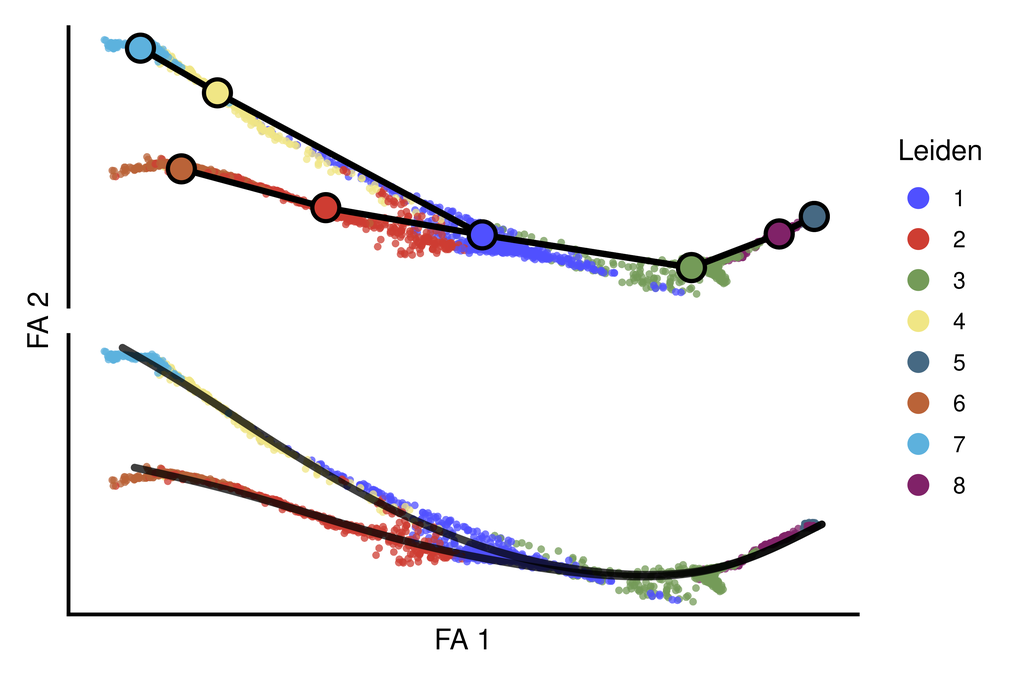

Figure 1: The MST and principal curves estimated by Slingshot overlaid on the force-directed graph embedding.

```r
p0 <- data.frame(Embeddings(seu_fish, "fdg")) %>%
      mutate(leiden = seu_fish$seurat_clusters) %>%
      ggplot(aes(x = FR_1, y = FR_2, color = leiden)) +
      geom_point(size = 1.5,
                 alpha = 0.75,
                 stroke = 0) +
      geom_path(data = sling_mst, mapping = aes(x = FR_1, y = FR_2, group = Lineage),
                linewidth = 1.25,
                color = "black") +
      geom_point(data = sling_mst, mapping = aes(x = FR_1, y = FR_2, fill = Cluster),
                color = "black",
                shape = 21,
                size = 4.5,
                stroke = 1.25,
                show.legend = FALSE) +
      scale_color_manual(values = palette_cluster) +
      scale_fill_manual(values = palette_cluster) +
      labs(x = "FA 1",
           y = "FA 2",
           color = "Leiden") +
      theme_scLANE(umap = TRUE) +
      guides(color = guide_legend(override.aes = list(size = 4, alpha = 1, stroke = 0.25)))
p1 <- data.frame(Embeddings(seu_fish, "fdg")) %>%
      mutate(leiden = seu_fish$seurat_clusters) %>%
      ggplot(aes(x = FR_1, y = FR_2, color = leiden)) +
      geom_point(size = 1.5,
                 alpha = 0.75,
                 stroke = 0) +
      geom_path(data = sling_curves,
                mapping = aes(x = FR_1, y = FR_2, group = Lineage),
                color = "black",
                linewidth = 1.5,
                alpha = 0.75,
                lineend = "round") +
      scale_color_manual(values = palette_cluster) +
      labs(x = "FA 1",
           y = "FA 2",
           color = "Leiden") +
      theme_scLANE(umap = TRUE) +
      guides(color = guide_legend(override.aes = list(size = 4, alpha = 1, stroke = 0.25)))
p2 <- (p0 / p1) + plot_layout(guides = "collect", axes = "collect")
p2
```

Since our pseudotime can be viewed as a smooth, continuous proxy of discrete experimental time, we’ve normalized it to $[0, 1]$ within each lineage.

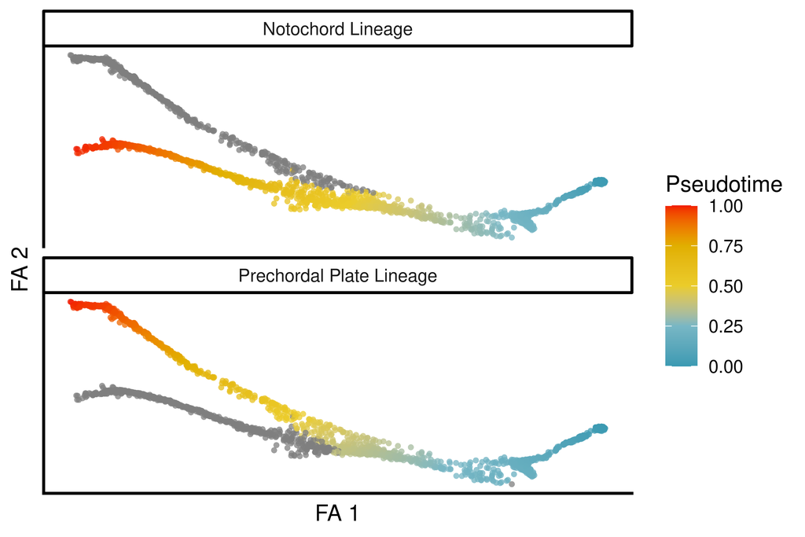

Figure 2: The force-directed graph embedding colored by lineage-specific pseudotime estimated by Slingshot.

```r
p3 <- data.frame(Embeddings(seu_fish, "fdg")) %>%
      bind_cols(sling_pt) %>%
      tidyr::pivot_longer(starts_with("Lineage"),
                          names_to = "lineage",
                          values_to = "pseudotime") %>%
      mutate(lineage_label = if_else(lineage == "Lineage2", "Notochord Lineage", "Prechordal Plate Lineage")) %>%
      ggplot(aes(x = FR_1, y = FR_2, color = pseudotime)) +
      facet_wrap(~lineage_label, nrow = 2) +
      geom_point(size = 1.5,
                 alpha = 0.75,
                 stroke = 0) +
      labs(x = "FA 1",
           y = "FA 2",
           color = "Pseudotime") +
      scale_color_gradientn(colors = palette_heatmap, labels = scales::label_number(accuracy = .01)) +
      theme_scLANE(umap = TRUE)
p3
```

## 4.2 Trajectory DE testing with `scLANE`

Finally, we perform trajectory DE testing using `scLANE`.

```r
candidate_genes <- chooseCandidateGenes(seu_fish,
                                        group.by.subject = FALSE,
                                        n.desired.genes = 4000L)
pt_df <- select(sling_pt, -c(PT_Overall, cell)) %>%
         as.data.frame() %>%
         magrittr::set_rownames(seu_fish$cell) %>%
         magrittr::set_colnames(c("PT_P", "PT_N"))
cell_offset <- createCellOffset(seu_fish)
scLANE_models <- testDynamic(seu_fish,
                             pt = pt_df,
                             genes = candidate_genes,
                             size.factor.offset = cell_offset,
                             n.cores = 16L,
                             verbose = FALSE)
```

```
scLANE testing in GLM mode completed for 4000 genes across 2 lineages in 6.806 mins
```

```r
scLANE_res_tidy <- getResultsDE(scLANE_models) %>%
                   mutate(Lineage_Name = if_else(Lineage == "A",
                                                 "Prechordal Plate Lineage",
                                                 "Notochord Lineage"))
```

## 4.3 `tradeSeq` DE analysis

```r
ts_start <- Sys.time()
bioc_par <- BiocParallel::MulticoreParam(workers = 16L, RNGseed = 312)
RNA_counts <- as.matrix(seu_fish@assays$RNA$counts)[candidate_genes, ]
ts_pt <- slingPseudotime(sling_res, na = FALSE) %>%
         as.data.frame() %>%
         mutate(across(contains("Lineage"), \(x) (x - min(x, na.rm = TRUE)) / (max(x, na.rm = TRUE) - min(x, na.rm = TRUE))))
k_eval <- evaluateK(RNA_counts,
                    pseudotime = ts_pt,
                    cellWeights = slingCurveWeights(sling_res),
                    offset = log(1 / cell_offset),
                    k = 3:10,
                    plot = FALSE,
                    nGenes = 500,
                    verbose = FALSE,
                    parallel = TRUE,
                    BPPARAM = bioc_par)
best_k <- c(3:10)[which.min(abs(colMeans(k_eval - rowMeans(k_eval))))]  # choose k w/ lowest MAD from mean AIC
ts_models <- fitGAM(RNA_counts,
                    pseudotime = ts_pt,
                    cellWeights = slingCurveWeights(sling_res),
                    offset = log(1 / cell_offset),
                    nknots = best_k,
                    sce = FALSE,
                    parallel = TRUE,
                    verbose = FALSE,
                    BPPARAM = bioc_par)
BiocParallel::bpstop(bioc_par)
ts_de_res <- associationTest(ts_models, global = TRUE) %>%
                             arrange(desc(waldStat)) %>%
                             mutate(gene = rownames(.),
                                    pvalue_adj = p.adjust(pvalue, method = "fdr"),
                                    gene_dynamic_overall = if_else(pvalue_adj < 0.01, 1, 0)) %>%
                             relocate(gene)
ts_end <- Sys.time()
ts_diff <- ts_end - ts_start
```

The runtime for `tradeSeq` with 5 knots per gene is:

```r
ts_diff
```

```
Time difference of 14.5253 mins
```

# 5 Save data

We save our `Seurat` object, `Slingshot` results, and output from `scLANE`.

```r
saveRDS(seu_fish, file = "../../data/zebrafish/seu_fish.Rds")
saveRDS(sling_res, file = "../../data/zebrafish/sling_res.Rds")
saveRDS(scLANE_models, file = "../../data/zebrafish/scLANE_models.Rds")
saveRDS(ts_models, file = "../../data/zebrafish/ts_models.Rds")
```